# R Notebook

# Packages to be installed

## Import the data from source location:

```r
bookings <- read_csv("C:/Users/sangeeta/Downloads/bookings.csv")
#View(bookings)
```

## Tidy the data

```r
bookings <- bookings %>% drop_na()
```

## Feature Engineering

### Parse Out Day of Week

```r
bookings$DayOfDeparture  = wday(mdy_hm(bookings$DepartureDate,locale = "English"),label = TRUE)
```

### Normalize Fare Per Person

```r
bookings$FarePP = bookings$Fare/bookings$PassengerCount
```

### Convert to FACTOR

```r
bookings$class = as.factor(bookings$InvClass)
bookings$orig = as.factor(bookings$Origin)
bookings$desti = as.factor(bookings$Destination)
```

## Forecasting Fares

### Data Preparation

```r
bookings %>% group_by(orig,desti) %>% tally(sort = TRUE) #indicates DATASET has DTW-LAS as highest number of flights
```

```
## Source: local data frame [726 x 3]
## Groups: orig [33]
##
##      orig  desti     n
##    <fctr> <fctr> <int>
## 1     DTW    LAS 40833
## 2     MSP    LAS 39681
## 3     DTW    MCO 37887
## 4     MSP    MCO 35350
## 5     DTW    LAX 32428
## 6     MSP    LAX 31270
## 7     DTW    TPA 25197
## 8     MSP    SFO 24329
## 9     DTW    ATL 23572
## 10    MSP    DEN 22892
## # ... with 716 more rows
```

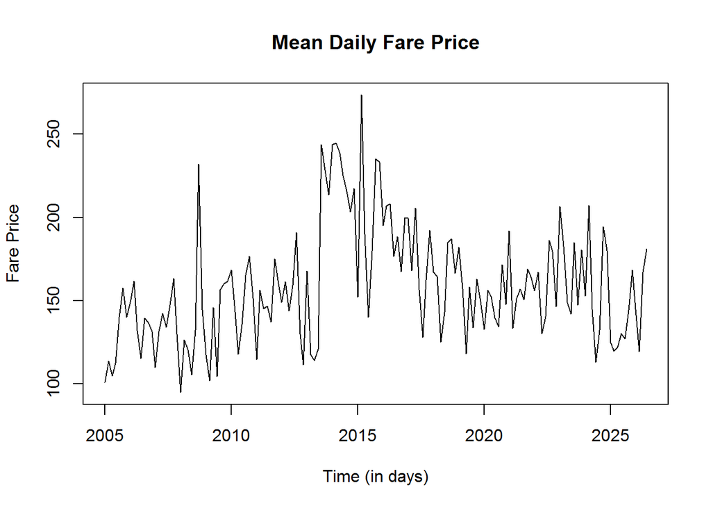

```r
df_LAS = bookings %>% dplyr::filter(orig == 'DTW' & desti == 'LAS') %>%
              select(DepartureDate,FarePP) %>%
              filter(FarePP > 0) %>%
              group_by(DepartureDate) %>%
              summarise(FarePP = mean(FarePP))

df_LAS$DepartureDate = mdy_hm(df_LAS$DepartureDate)
df_LAS$FarePP = round(df_LAS$FarePP,digits = 2)

tsdf_LAS = ts(df_LAS$FarePP, start = c(2005,1),frequency = 7)
# Set frequency of 7 since dataset has only 5 months of data for one year, therefore accounting for weekly seasonality only.

plot(tsdf_LAS,
     lwd=1,
     #xaxt= "n",
     ylab = "Fare Price",
     xlab = "Time (in days)",
     main = "Mean Daily Fare Price")
```

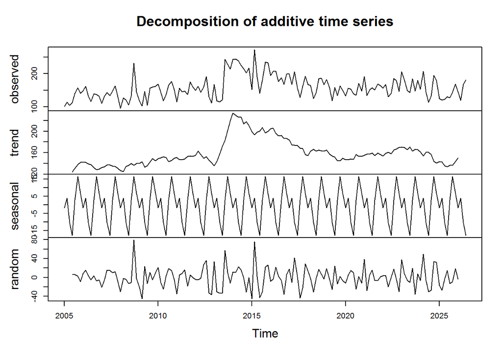

```r
plot(decompose(tsdf_LAS))
```

```r
# Did not use zoo package since there are no arbitrary gaps in the time series
```

### Split Data into 3 - train, test and validation

```r
nValidation = 31
nTrain = length(tsdf_LAS) - nValidation
train.ts = window(tsdf_LAS,start = c(2005,1),end = c(2005,nTrain))
valid.ts = window(tsdf_LAS,start = c(2005,nTrain + 1),end = c(2005,nTrain + nValidation))
```

Naive Forecast (Quadratic model)

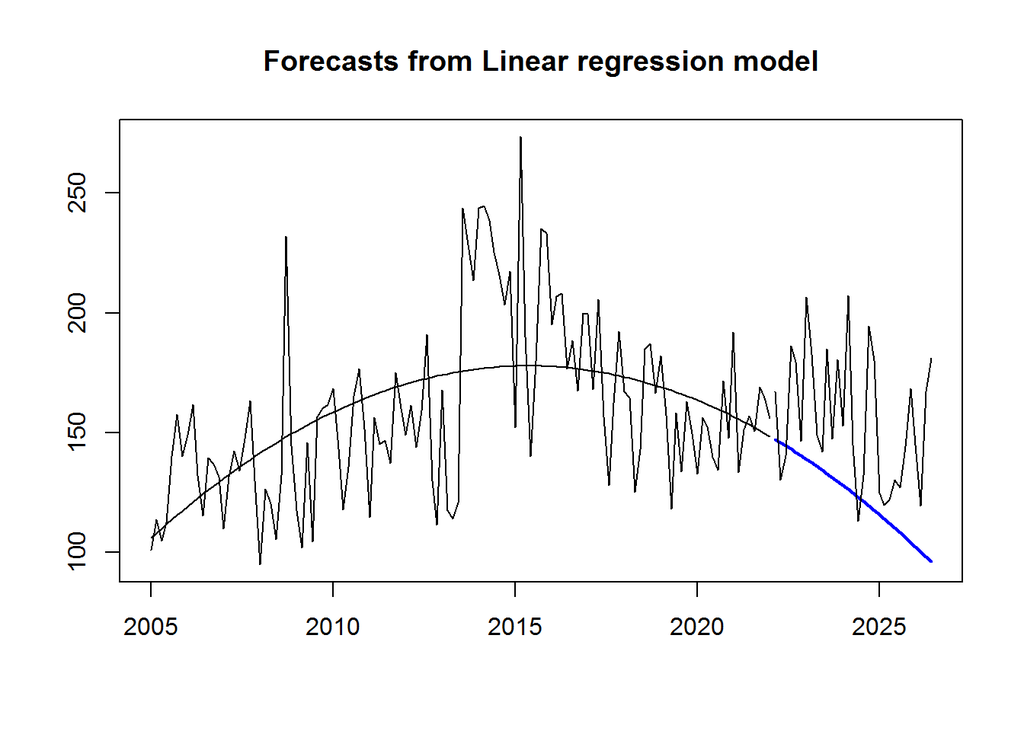

```r
AlFc.lm = tslm(train.ts ~ trend + I(trend^2))
AlFc.lm.pred = forecast(AlFc.lm,h = nValidation,level = 0)
plot(AlFc.lm.pred)
lines(AlFc.lm$fitted,lwd = 1)
lines(valid.ts)
```

```r
accuracy(AlFc.lm.pred$mean,valid.ts)
```

```
##                ME     RMSE      MAE      MPE     MAPE      ACF1 Theil's U
## Test set 31.74632 41.83077 33.66933 18.50892 20.04505 0.1685585  1.273043
```

### Smoothing Method - Moving Average

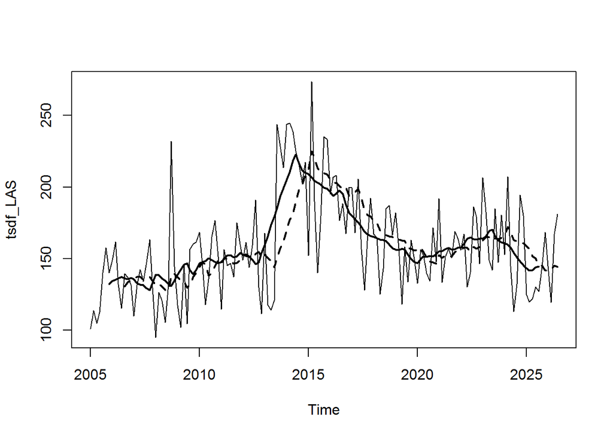

```r
ma.trailing = rollmean(tsdf_LAS,k=12,align = "right") #calculates trailing moving average
ma.centered = ma(tsdf_LAS,order = 12) #creates a centered moving average
plot(tsdf_LAS)
lines(ma.centered,lwd=2)
lines(ma.trailing,lwd=2,lty=2)
legend(2005,c("Actual Time Series","Centered Moving Average","Trailing Moving Average"),lty = c(1,1,2),lwd = c(1,2,2), bty = "n")
```

Notice that the seasonality is not captured in the forecast. This is a clear indication that the moving average method can be used for forecasting only in series that lack seasonality and trend. An alternative approach would be to de-trend and deseasonalize the series, use the forecast, and then add trend and seasonality back into the forecast.

### Trailing Moving Average forecaster

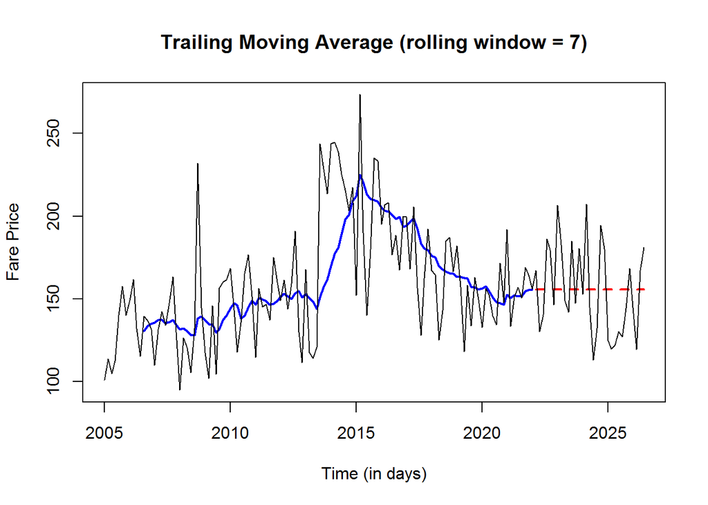

```r
nValidation = 31
nTrain = length(tsdf_LAS)- nValidation
train.ts = window(tsdf_LAS,start=c(2005,1),end=c(2005,nTrain))
valid.ts = window(tsdf_LAS,start = c(2005,nTrain + 1), end=c(2005,nTrain + nValidation))
ma.trailing = rollmean(train.ts,k=12,align="right")
last.ma = tail(ma.trailing,1)
ma.trailing.pred = ts(rep(last.ma,nValidation),start = c(2005,nTrain+1),end=c(2005,nTrain+nValidation),frequency = 7)
plot(tsdf_LAS,
     lwd=1,
     ylab = "Fare Price",
     xlab = "Time (in days)",
     main = "Trailing Moving Average (rolling window = 7)")
lines(ma.trailing,lwd = 2, col = "blue")
lines(ma.trailing.pred,lwd = 2, col = "red", lty = 2)
lines(tsdf_LAS)
```

Differencing is another method applied to remove trend and seasonality from the time series. However for data driven forecasting methods such as neural networks, differencing appears to produce inferior results as seen later.

### Simple Exponential Smoothing

- A weighted average of past values.
- Use only for series that have no trend or seasonality.
- **ets** function in **forecast** package : error, trend, seasonality

```r
diff.twice.ts = diff(diff(tsdf_LAS,lag = 12), lag = 1)
nValidation = 31
nTrain = length(diff.twice.ts) - nValidation
train.ts.diff = window(diff.twice.ts, start = c(2005,2), end = c(2005,nTrain+1))
vaild.ts.diff = window(diff.twice.ts, start = c(2005,nTrain+2),end = c(2005,nTrain+1+nValidation))

ses = ets(train.ts.diff,model = "ANN", alpha = 0.2)
ses.pred = forecast(ses,h = nValidation, level = 0)
ses.pred
```

```
##          Point Forecast     Lo 0     Hi 0
## 2020.429       -5.01985 -5.01985 -5.01985
## 2020.571       -5.01985 -5.01985 -5.01985
## 2020.714       -5.01985 -5.01985 -5.01985
## 2020.857       -5.01985 -5.01985 -5.01985
## 2021.000       -5.01985 -5.01985 -5.01985
## 2021.143       -5.01985 -5.01985 -5.01985
## 2021.286       -5.01985 -5.01985 -5.01985
## 2021.429       -5.01985 -5.01985 -5.01985
## 2021.571       -5.01985 -5.01985 -5.01985
## 2021.714       -5.01985 -5.01985 -5.01985
## 2021.857       -5.01985 -5.01985 -5.01985
## 2022.000       -5.01985 -5.01985 -5.01985
## 2022.143       -5.01985 -5.01985 -5.01985
## 2022.286       -5.01985 -5.01985 -5.01985
## 2022.429       -5.01985 -5.01985 -5.01985
## 2022.571       -5.01985 -5.01985 -5.01985
## 2022.714       -5.01985 -5.01985 -5.01985
## 2022.857       -5.01985 -5.01985 -5.01985
## 2023.000       -5.01985 -5.01985 -5.01985
## 2023.143       -5.01985 -5.01985 -5.01985
## 2023.286       -5.01985 -5.01985 -5.01985
## 2023.429       -5.01985 -5.01985 -5.01985
## 2023.571       -5.01985 -5.01985 -5.01985
## 2023.714       -5.01985 -5.01985 -5.01985
## 2023.857       -5.01985 -5.01985 -5.01985
## 2024.000       -5.01985 -5.01985 -5.01985
## 2024.143       -5.01985 -5.01985 -5.01985
## 2024.286       -5.01985 -5.01985 -5.01985
## 2024.429       -5.01985 -5.01985 -5.01985
## 2024.571       -5.01985 -5.01985 -5.01985
## 2024.714       -5.01985 -5.01985 -5.01985
```

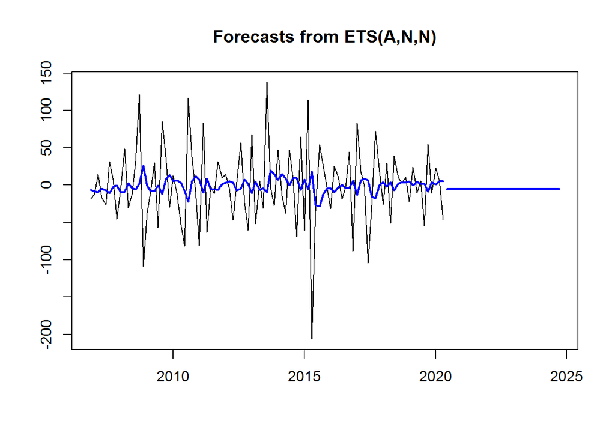

```r
plot(ses.pred)
lines(ses.pred$fitted, lwd = 2, col = "blue")
```

```r
?ets
```

```
## starting httpd help server ...
```

```
##  done
```

### Performance comparison of two simple exponential smoothing models - Fixed alpha & Optimal alpha

```r
ses.opt = ets(train.ts,model = "ZAA")
ses.opt.pred = forecast(ses.opt,h = nValidation,level = 0)
accuracy(ses.pred,valid.ts)
```

```
##                        ME      RMSE       MAE      MPE     MAPE      MASE
## Training set   0.06395525  58.05716  42.63778 107.8542 117.0698 0.7742294
## Test set     167.55721874 169.65165 167.55722 103.1743 103.1743 3.0425534
##                     ACF1 Theil's U
## Training set -0.35667727        NA
## Test set     -0.05302587  4.377326
```

```r
accuracy(ses.opt.pred,valid.ts)
```

```
##                      ME     RMSE      MAE      MPE     MAPE      MASE
## Training set  -1.037844 27.18483 20.14161 -2.95084 12.84568 0.6576880
## Test set     -10.469399 28.84666 23.40596 -9.66699 16.39450 0.7642796
##                   ACF1 Theil's U
## Training set 0.1361734        NA
## Test set     0.2621796 0.9396426
```

```r
ses.opt
```

```
## ETS(M,A,A)
##
## Call:
##  ets(y = train.ts, model = "ZAA")
##
##   Smoothing parameters:
##     alpha = 0.2496
##     beta  = 1e-04
##     gamma = 1e-04
##
##   Initial states:
##     l = 124.5364
##     b = 0.5391
##     s=5.0859 17.3377 6.7165 -17.2551 -9.245 0.9644
##            -3.6044
##
##   sigma:  0.1652
##
##      AIC     AICc      BIC
## 1380.901 1383.817 1414.351
```

### Series with Trend - Double Exponential Smoothing/Holt’s Linear model

For additive trend, use option = “AMN”. For multiplicative trend, use option = “MMN”.

## Series with Trend and Seasonality - Holt Winters Exponential Smoothing

Use option = “MAA” (Multiplicative error, Additive trend, Additive seasonality)

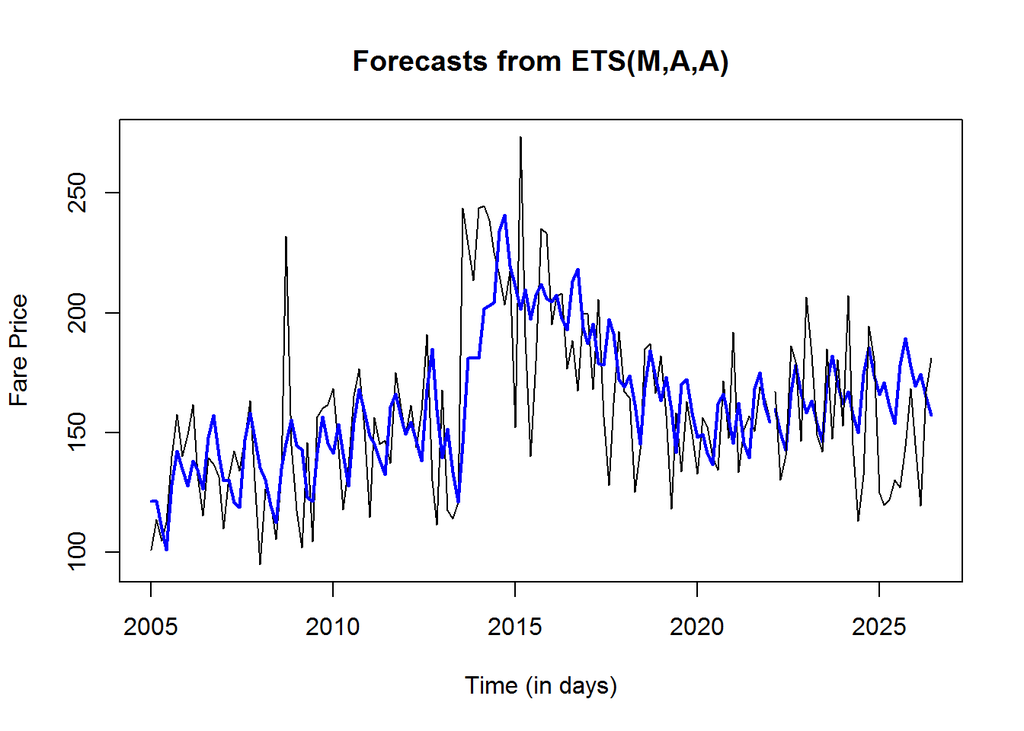

```r
hwin = ets(train.ts,model = "MAA")
hwin.pred = forecast(hwin,h=nValidation,level = 0)
plot(hwin.pred,
     lwd=1,
     ylab = "Fare Price",
     xlab = "Time (in days)")
lines(hwin.pred$fitted,lwd=2,col="blue")
lines(valid.ts)
```

```r
accuracy(hwin.pred,valid.ts)
```

```
##                      ME     RMSE      MAE      MPE     MAPE      MASE
## Training set  -1.037844 27.18483 20.14161 -2.95084 12.84568 0.6576880
## Test set     -10.469399 28.84666 23.40596 -9.66699 16.39450 0.7642796
##                   ACF1 Theil's U
## Training set 0.1361734        NA
## Test set     0.2621796 0.9396426
```

### Linear Trend Model

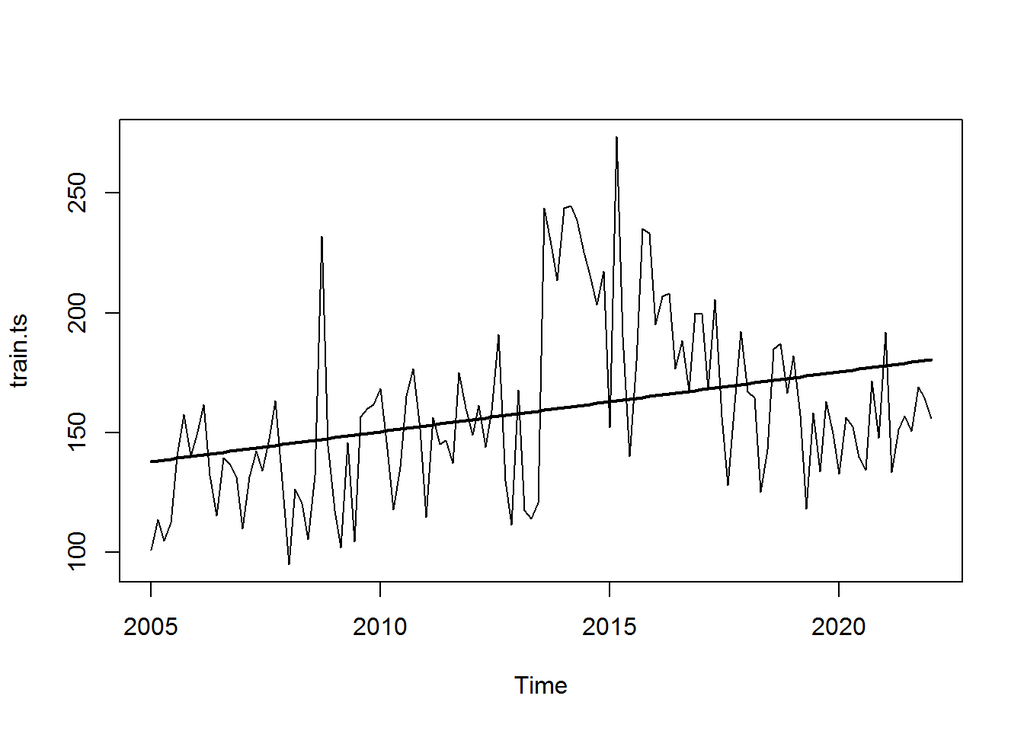

```r
train.lm = tslm(train.ts ~ trend)
plot(train.ts)
lines(train.lm$fitted,lwd=2)
```

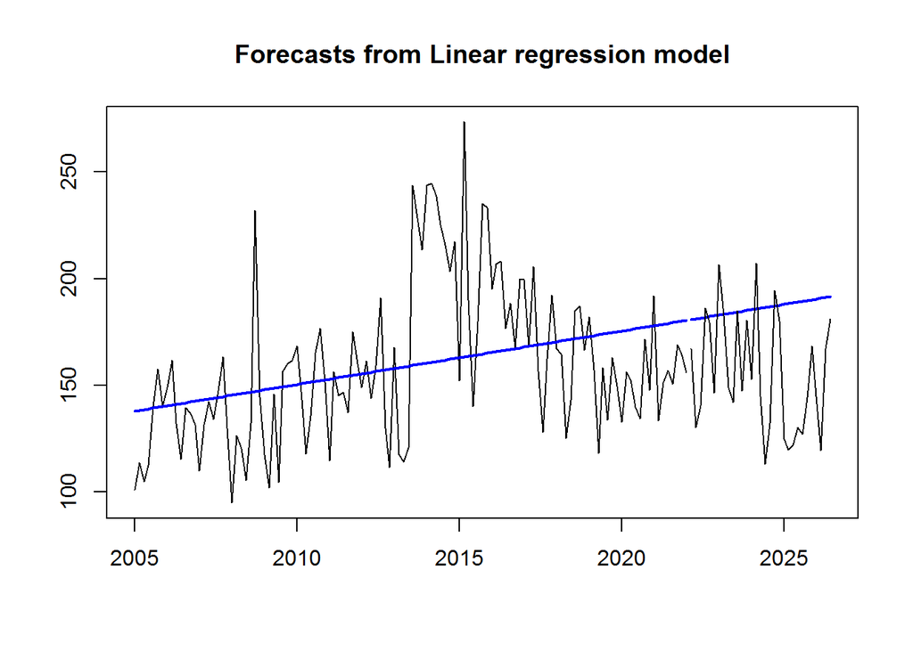

```r
train.lm.pred = forecast(train.lm,h=nValidation,level = 0)
plot(train.lm.pred)
lines(train.lm.pred$fitted,lwd=2,col="blue")
lines(valid.ts)
```

### AR(1) model

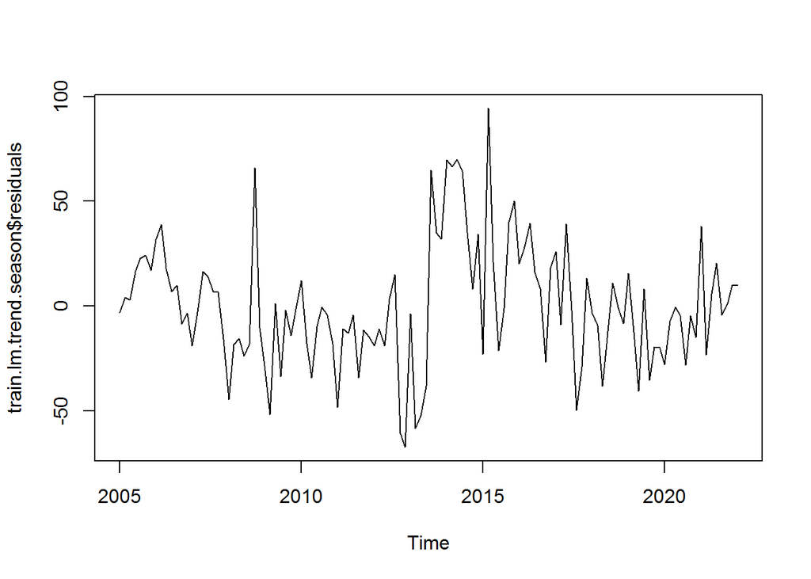

```r
train.lm.trend.season = tslm(train.ts ~ trend + I(trend^2) + season)
train.res.arima = Arima(train.lm.trend.season$residuals,order = c(1,0,0))
train.aes.arima.pred = forecast(train.res.arima,h = nValidation)
plot(train.lm.trend.season$residuals)
plot(train.lm.trend.season$residuals)
lines(train.res.arima$fitted,lwd = 2, col = "blue")
```

### Neural Networks for Forecasting

- Can be used to generate numerical and binary forecasts
- Highly data-driven and computationally expensive
- **BLACK BOX**
- Supermacy of their accuracy in comparison to other methods is a hit or miss
- Input layer, Hidden layer, Output layer
- Hidden layer is a weighted sum of the inputs to which an activation function is applied
- External information is the secret sauce rather than its forecasting prowess
- Law and Au used a NN for forecasting Japanese tourism outperforming all naive forecasts
- Input layer comprised 6 nodes:
  - Service Price
  - Average Hotel Rate
  - Foreign Exchange rate
  - Population
  - Marketing expenses
  - Gross Domestic Expenditure
- *Forecast* package has **nnetar** function for neural networks autoregression
- A rendition of the avNNet in R by HYndman and Athanasopoulos
- Have to scale predictors and response in [0,1] or [-1,1]. Forecast does this for you.
- Deseasonalize and De-trend to improve performance of neural networks
- Regression
- Exponential smoothing
- Exception of differencing
- 4 main arguments of the nnetar function:
- repeats : controls the number of neural networks fit
- p (Non-seasonal lags) : Chosen based on best-fit AR(p) model
- P (seasonal lags) : Last observed value from the same season
- size : Number of nodes in hidden layer (nnetar allows only one hidden layer)
- Denoted by NNAR(p,P,size)
- Uses the logit activation function to map inputs to hidden node values
- From hidden node to output value, nnetar uses linear or logit function
- linout = TRUE, continuous range
- linout = FALSE, output is a probability

```r
set.seed(90)
FarePP.nnetar = nnetar(train.ts,repeats = 20,p = 11,P=1,size=7)
summary(FarePP.nnetar$model[[1]])
```

```
## a 11-7-1 network with 92 weights
## options were - linear output units
##   b->h1  i1->h1  i2->h1  i3->h1  i4->h1  i5->h1  i6->h1  i7->h1  i8->h1
##    6.74   -3.72    7.17    8.96    3.19   -0.85  -14.60   -2.23    9.15
##  i9->h1 i10->h1 i11->h1
##   -2.70   -3.44  -13.41
##   b->h2  i1->h2  i2->h2  i3->h2  i4->h2  i5->h2  i6->h2  i7->h2  i8->h2
##   -2.00   17.58   -6.40   -1.67    8.59   -5.26   13.05   -1.26    4.16
##  i9->h2 i10->h2 i11->h2
##   -4.18    1.64    1.91
##   b->h3  i1->h3  i2->h3  i3->h3  i4->h3  i5->h3  i6->h3  i7->h3  i8->h3
##    2.10   -0.14   -0.07    1.22    1.68   -0.20    0.50   -1.35   -0.93
##  i9->h3 i10->h3 i11->h3
##    1.64   -1.98    0.07
##   b->h4  i1->h4  i2->h4  i3->h4  i4->h4  i5->h4  i6->h4  i7->h4  i8->h4
##    1.31    2.74   -0.36   -3.08   -9.55   20.03    1.03   -0.10   14.72
##  i9->h4 i10->h4 i11->h4
##  -18.53    3.68    6.07
##   b->h5  i1->h5  i2->h5  i3->h5  i4->h5  i5->h5  i6->h5  i7->h5  i8->h5
##   -0.98    1.84    0.73    1.49   -0.52    0.74    2.34   -0.91    0.16
##  i9->h5 i10->h5 i11->h5
##    1.32   -1.19   -0.37
##   b->h6  i1->h6  i2->h6  i3->h6  i4->h6  i5->h6  i6->h6  i7->h6  i8->h6
##   -6.06    1.49   16.79   18.20  -24.01  -23.14    9.02    5.18  -12.63
##  i9->h6 i10->h6 i11->h6
##    5.93   11.31    0.87
##   b->h7  i1->h7  i2->h7  i3->h7  i4->h7  i5->h7  i6->h7  i7->h7  i8->h7
##   -4.62   -0.11   -0.15   -0.48    0.43   -3.62    9.26   -1.34   -5.18
##  i9->h7 i10->h7 i11->h7
##   -2.52    0.12    7.84
##   b->o  h1->o  h2->o  h3->o  h4->o  h5->o  h6->o  h7->o
##   1.52   2.10  -1.12  -4.14  -1.50   4.20  -2.15   2.70
```

```r
FarePP.nnetar.pred = forecast(FarePP.nnetar,h=nValidation)
accuracy(FarePP.nnetar.pred,valid.ts)
```

```
##                        ME      RMSE       MAE       MPE      MAPE
## Training set -0.008920975  2.441515  1.791042 -0.169121  1.171126
## Test set      1.073912736 28.173725 25.221093 -2.208241 16.517315
##                    MASE        ACF1 Theil's U
## Training set 0.05848325 -0.01824453        NA
## Test set     0.82354946  0.06818281 0.8759729
```

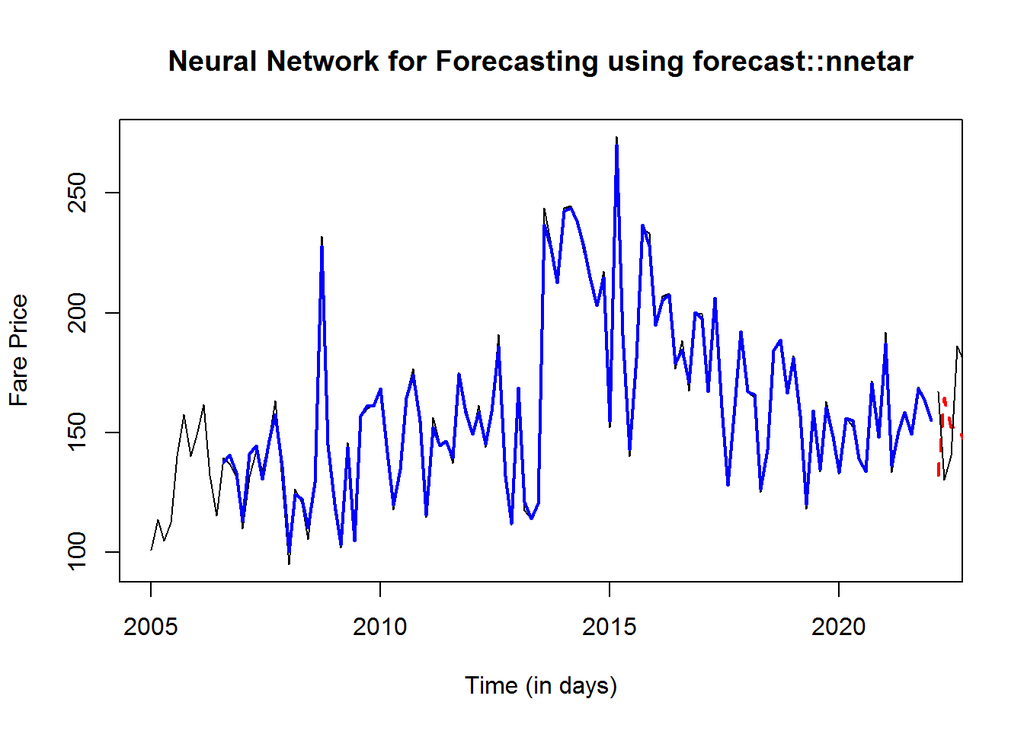

```r
plot(train.ts,
     lwd=1,
     ylab = "Fare Price",
     xlab = "Time (in days)",
     main = "Neural Network for Forecasting using forecast::nnetar")
# lines(hwin.pred$fitted,lwd=2,col="blue")
lines(FarePP.nnetar.pred$fitted,lwd=2,col="blue")
lines(FarePP.nnetar.pred$mean,lwd=2,col="red",lty=2)
lines(valid.ts)
```

```r
accuracy(FarePP.nnetar.pred,valid.ts)
```

```
##                        ME      RMSE       MAE       MPE      MAPE
## Training set -0.008920975  2.441515  1.791042 -0.169121  1.171126
## Test set      1.073912736 28.173725 25.221093 -2.208241 16.517315
##                    MASE        ACF1 Theil's U
## Training set 0.05848325 -0.01824453        NA
## Test set     0.82354946  0.06818281 0.8759729
```